# Rajmati_Marlecha

#### RajmatiGM : DMG 2 Assigment

###### PGID : 11810109

```python
import warnings
import pandas as pd
warnings.filterwarnings('ignore')
pd.set_option('float_format', '{:f}'.format)
pd.set_option('display.max_columns', None)
pd.set_option('precision', 4)
```

```python
# loading important libraries
import numpy as np
import matplotlib.pyplot as plt
%matplotlib inline
from scipy.stats import norm
import pandas_profiling
import numpy as np
from sklearn.decomposition import PCA
from sklearn.cluster import KMeans
np.random.seed(sum(map(ord, "aesthetics")))
import glob
import seaborn as sns
import math
from pomegranate import *
from os import walk
from sklearn.discriminant_analysis import LinearDiscriminantAnalysis
from sklearn import metrics
from sklearn import preprocessing
from sklearn.naive_bayes import GaussianNB
from sklearn.naive_bayes import MultinomialNB

from sklearn.neighbors import KNeighborsClassifier
from sklearn.tree import DecisionTreeClassifier
from sklearn.neighbors import KernelDensity
from sklearn.preprocessing import StandardScaler
from sklearn.preprocessing import Normalizer
```

```python
#function to get train and test files for a folder path
def getFileNames(path):
    files = []
    for (dirp, dirn, filen) in walk(path):
        files.extend(filen)
        break
    print(files)
    labelsTrain = []
    labelsTest = []
    fileNameTrain = []
    fileNameTest = []
    for f in files:
        if f.startswith('train'):
            labelsTrain.append(int(f.replace('train','').replace('.csv','')))
            fileNameTrain.append(f)
        elif f.startswith('test'):
            labelsTest.append(int(f.replace('test','').replace('.csv','')))
            fileNameTest.append(f)


    summaryFileDf_train= pd.DataFrame({'fileName': fileNameTrain ,'labelsTrain': labelsTrain})
    summaryFileDf_test= pd.DataFrame({'fileName': fileNameTest ,'labelsTest': labelsTest})
    return summaryFileDf_train,summaryFileDf_test
```

```python
#function to read the csv files in a folder path where there are multiple train test files
def readFiles(path,header):
    FileDf_train,FileDf_test = getFileNames(path)
    print(FileDf_train.head())
    print(FileDf_test.head())
    traindataset = pd.DataFrame()
    testdataset = pd.DataFrame()
    for f in FileDf_train.iterrows():
        tempdf = {}
        file = path + f[1]['fileName']
        if(header == False):
            tempdf = pd.read_csv(file,skiprows=[0],header=None)
        else:
            tempdf = pd.read_csv(file)
            print(1)
        if len(FileDf_train) > 1:
            print('multi' + str(f[1]['labelsTrain']))
            tempdf['Label'] = f[1]['labelsTrain']
            traindataset =  pd.concat([traindataset,tempdf])
        else:
            traindataset = tempdf
    for f in FileDf_test.iterrows():
        tempdftest = {}
        file = path + f[1]['fileName']
        #print(file)
        if(header == False):
            tempdftest = pd.read_csv(file,skiprows=[0],header=None)
            #print(2)
        else:
            tempdftest = pd.read_csv(file)
            #print(1)
        if len(FileDf_test) > 1:
            #print('multi')
            tempdftest['Label'] = f[1]['labelsTest']
            testdataset = pd.concat([testdataset,tempdftest])
        else:
            testdataset = tempdftest

    return traindataset,testdataset
```

# Q1 : Fisher on IRIS

```python
iris_train = pd.read_csv('/Users/rajmati.marlecha/Desktop/Term3/DMG2/iris/train.csv')
iris_test = pd.read_csv('/Users/rajmati.marlecha/Desktop/Term3/DMG2/iris/test.csv')

print(iris_train.shape)
print(iris_test.shape)
print(iris_train.columns)
print(iris_test.columns)
print(iris_train.Species.unique())
```

```
(97, 6)
(53, 6)
Index(['Unnamed: 0', 'Sepal.Length', 'Sepal.Width', 'Petal.Length',
       'Petal.Width', 'Species'],
      dtype='object')
Index(['Unnamed: 0', 'Sepal.Length', 'Sepal.Width', 'Petal.Length',
       'Petal.Width', 'Species'],
      dtype='object')
['setosa' 'versicolor' 'virginica']
```

#### Looking at the scatter plots (on train dataset) below for different pairs of columns plotted side by side with color marked on the class , we can clearly see that versicolor and virginica are similar to each other.Hence we will use those two to form one class as a meta-class and keep setosa as is

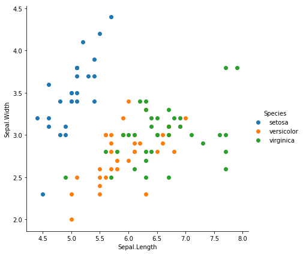

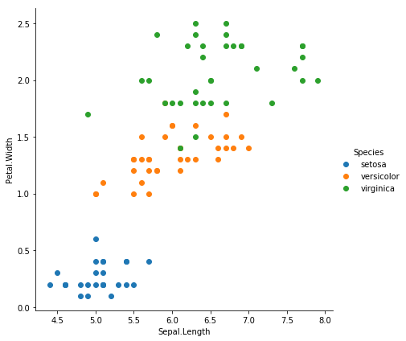

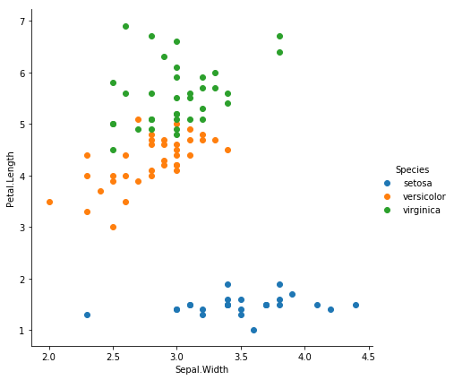

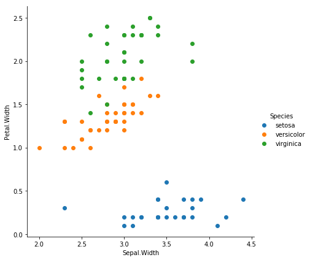

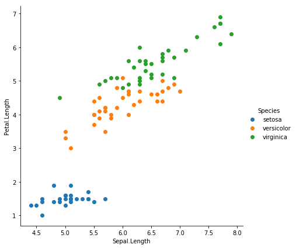

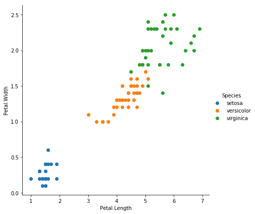

```python
g = sns.FacetGrid(iris_train, hue="Species",height=(6))
g = (g.map(plt.scatter, "Sepal.Length", "Sepal.Width").add_legend())
g = sns.FacetGrid(iris_train,  hue="Species",height=(6))
g = (g.map(plt.scatter, "Sepal.Length", "Petal.Width").add_legend())
g = sns.FacetGrid(iris_train,  hue="Species",height=(6))
g = (g.map(plt.scatter, "Sepal.Width", "Petal.Length").add_legend())
g = sns.FacetGrid(iris_train,  hue="Species",height=(6))
g = (g.map(plt.scatter, "Sepal.Width", "Petal.Width").add_legend())
g = sns.FacetGrid(iris_train,  hue="Species",height=(6))
g = (g.map(plt.scatter, "Sepal.Length", "Petal.Length").add_legend())
g = sns.FacetGrid(iris_train,  hue="Species",height=(6))
g = (g.map(plt.scatter, "Petal.Length", "Petal.Width").add_legend())
```

```python
iris_train['derived_Class'] = iris_train.Species.apply(lambda x:'meta-class' if x=='versicolor' or x=='virginica' else x )
print(iris_train['derived_Class'].unique())
print(iris_train.shape)
print(iris_test.shape)
```

```
['setosa' 'meta-class']
(97, 7)
(53, 6)
```

```python
iris_train.head()
```

|  | Unnamed: 0 | Sepal.Length | Sepal.Width | Petal.Length | Petal.Width | Species | derived_Class |
| --- | --- | --- | --- | --- | --- | --- | --- |
| 0 | 1 | 5.100000 | 3.500000 | 1.400000 | 0.200000 | setosa | setosa |
| 1 | 2 | 4.900000 | 3.000000 | 1.400000 | 0.200000 | setosa | setosa |
| 2 | 4 | 4.600000 | 3.100000 | 1.500000 | 0.200000 | setosa | setosa |
| 3 | 6 | 5.400000 | 3.900000 | 1.700000 | 0.400000 | setosa | setosa |
| 4 | 8 | 5.000000 | 3.400000 | 1.500000 | 0.200000 | setosa | setosa |

- In below code , since the labels were text , before feeding to the model we apply lable endcoder.
- Also as a pre-processsing step we Standardize the column values
- We apply LDA on the differnt data sets - one that was formed with the meta class and the other where we only take the two classes that were merged in the first ( virginica and versicolor )

```python
from sklearn.preprocessing import StandardScaler
sc = StandardScaler()
labEncoder = preprocessing.LabelEncoder()
iris_train['Species'] = labEncoder.fit_transform(iris_train['Species'] )
#iris_test['Species'] = labEncoder.fit_transform(iris_test['Species'] )

iris_train['derived_Class'] = labEncoder.fit_transform(iris_train['derived_Class'])

X_train_first = iris_train.iloc[:, 1:5]
X_train_second = iris_train[iris_train.Species !=0].iloc[:, 1:5]

X_train_first = sc.fit_transform(X_train_first)
X_train_second = sc.fit_transform(X_train_second)

Y_train_first = iris_train.iloc[:,6]
Y_train_second =iris_train[iris_train.Species !=0].iloc[:,5] # old classes # 0 label for setosa # only took columns

X_test = iris_test.iloc[:, 1:5]
Y_test = iris_test.iloc[:,5]

X_test = sc.fit_transform(X_test)
```

```python
#fitted LDA on training
lda_first = LinearDiscriminantAnalysis(n_components=1)
firstmodel = lda_first.fit(X_train_first, Y_train_first)

lda_second = LinearDiscriminantAnalysis(n_components=1)
secondmodel = lda_second.fit(X_train_second, Y_train_second)

#transformed on test dataset
firstmodel = firstmodel.transform(X_test)
secondmodel = secondmodel.transform(X_test)
```

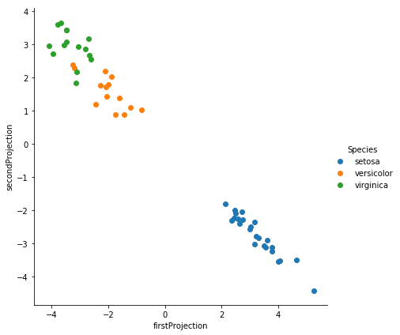

```python
#firstProjection = firstmodel.predict(X_test)
#secondProjection = secondmodel.predict(X_test)
#test = firstmodel.ravel()
projectedDf = pd.DataFrame({'firstProjection':firstmodel.ravel(),'secondProjection':secondmodel.ravel(),'Species': Y_test})
g = sns.FacetGrid(projectedDf, hue="Species",height=(6))
g = (g.map(plt.scatter, "firstProjection", "secondProjection").add_legend())
```

#### Summary : Looking above at the projections and the corresponding label output we can see that the two projections help seperate the classes well together. The first projection seperates Setosa with the other two classes . And the second projection further helps seggregate between versicolor and virginica

# Q2 : InfoGain on MushroomDataSet

```python
#For Q2 and Q3 loaded
mushroom_train = pd.read_csv('/Users/rajmati.marlecha/Desktop/Term3/DMG2/Mushroom/train.csv')
mushroom_test = pd.read_csv('/Users/rajmati.marlecha/Desktop/Term3/DMG2/Mushroom/test.csv')
```

```python
print(mushroom_train.V1.unique())
print(mushroom_test.V1.unique())
```

```
['p' 'e']
['e' 'p']
```

```python
def parameterstoUse(col,val,df,totalColSum):
    partition = df[df[col]==val]
    sizeofPartition = partition.shape[0]
    classpPart = partition[partition['V1']=='p'].shape[0]
    classePart = partition[partition['V1']=='e'].shape[0]
    maxClass = max(classpPart,classePart)
    #print(str(classpPart) + "********" + str(classePart))
    #print("maxClass" + str(maxClass))
    #print("sizeofPartition" + str(sizeofPartition))
    prob = round(sizeofPartition/totalColSum,4)
    return classpPart,classePart,maxClass,sizeofPartition,prob

def calculateAccuracy(col,val,df,totalColSum):
    classpPart,classePart,maxClass,sizeofPartition,prob= parameterstoUse(col,val,df,totalColSum)
    accuracy = round(maxClass/sizeofPartition,4)
    return accuracy,prob


def calculateGINIIndex(col,val,df,totalColSum):
    classpPart,classePart,maxClass,sizeofPartition,prob= parameterstoUse(col,val,df,totalColSum)
    classpProb = classpPart/sizeofPartition
    classeProb = classePart/sizeofPartition
    giniIndex = round((classpProb * classpProb) + (classeProb*classeProb),4)
    return giniIndex,prob

def calculateEntropy(col,val,df,totalColSum,baseval):
    classpPart,classePart,maxClass,sizeofPartition,prob= parameterstoUse(col,val,df,totalColSum)
    classpProb = classpPart/sizeofPartition
    classeProb = classePart/sizeofPartition
    #print(str(classpProb) + "____" + str(classeProb))
    e1p = 0
    e1e = 0
    if classpProb > 0:
        e1p = -classpProb*math.log(classpProb,baseval)
    if  classeProb > 0:
        e1e = -classeProb*math.log(classeProb,baseval)
        #print(e1e)
    entropy =  round(e1p+e1e,4)
    return entropy,prob
```

```python
columnList = list(mushroom_train.iloc[:,2:])
part = {}
resultFeat = []
resultAcc = []
resultGini = []
resultEntropy = []

for col in columnList:
    if col!='V17':
        totalAccuracy = 0
        totalginiIndex = 0
        totalEntropy = 0
        accuracy = 0
        part= mushroom_train[col].unique()
        #print("len" + str(len(part)))
        totalColSum = mushroom_train[col].shape[0]
        for val in part:
            #mushroom_train[i==val].shape[0]
            #print(col)
            #print(val)
            accuracy,prob = calculateAccuracy(col,val,mushroom_train,totalColSum)
            #print("Accuracy" + str(accuracy))
            #print(prob)
            totalAccuracy = round(totalAccuracy + prob * accuracy,4)
            gini,prob = calculateGINIIndex(col,val,mushroom_train,totalColSum)
            totalginiIndex = round(totalginiIndex + prob * gini,4)
            baseval = len(part)
            #print("baseval" + str(baseval))
            entropy,prob = calculateEntropy(col,val,mushroom_train,totalColSum,baseval)
            totalEntropy = round(totalEntropy + prob * entropy,4)
        #print("Total Acc"  + str(totalAccuracy))
        #print("Total gini"  + str(totalginiIndex))
       # print("Total entropy"  + str(totalEntropy))
        resultFeat.append(col)
        resultAcc.append(totalAccuracy)
        resultGini.append(totalginiIndex)
        resultEntropy.append(1-totalEntropy)
summaryDf= pd.DataFrame({'Feature_name': resultFeat ,'Accuracy': resultAcc ,'GINI Index': resultGini ,'1-Entropy': resultEntropy })
```

#### Summary Q2 :

- Created three methods as above to calculate Accuracy , GINI Index and 1-Entropy using the formulae explained in class
- Further also applied normalization by taking region probability across the feature to balance the dataset region counts for that feature
- Below is the summary of values

```python
summaryDf
```

|  | Feature_name | Accuracy | GINI Index | 1-Entropy |
| --- | --- | --- | --- | --- |
| 0 | V2 | 0.562500 | 0.529600 | 0.631700 |
| 1 | V3 | 0.578500 | 0.519600 | 0.514500 |
| 2 | V4 | 0.600500 | 0.527600 | 0.711500 |
| 3 | V5 | 0.745700 | 0.628100 | 0.196300 |
| 4 | V6 | 0.984700 | 0.970400 | 0.969700 |
| 5 | V7 | 0.518700 | 0.509700 | 0.016600 |
| 6 | V8 | 0.613200 | 0.559900 | 0.099600 |
| 7 | V9 | 0.757800 | 0.647900 | 0.233900 |
| 8 | V10 | 0.815600 | 0.741800 | 0.842300 |
| 9 | V11 | 0.546300 | 0.504600 | 0.006700 |
| 10 | V12 | 0.637100 | 0.566200 | 0.555300 |
| 11 | V13 | 0.770200 | 0.667700 | 0.637200 |
| 12 | V14 | 0.766100 | 0.665700 | 0.636600 |
| 13 | V15 | 0.719800 | 0.640400 | 0.766000 |
| 14 | V16 | 0.717700 | 0.633200 | 0.760600 |
| 15 | V18 | 0.520000 | 0.513000 | 0.513100 |
| 16 | V19 | 0.538800 | 0.524000 | 0.394200 |
| 17 | V20 | 0.780900 | 0.686700 | 0.709600 |
| 18 | V21 | 0.869200 | 0.785900 | 0.838200 |
| 19 | V22 | 0.726300 | 0.622700 | 0.693900 |
| 20 | V23 | 0.691300 | 0.597100 | 0.699700 |

```python
# This is the max across various measures of Purity , we can see V6 is max across all the three
print(summaryDf[summaryDf['GINI Index'] == max(summaryDf['GINI Index'])])
print(summaryDf[summaryDf['Accuracy'] == max(summaryDf['Accuracy'])])
print(summaryDf[summaryDf['1-Entropy'] == max(summaryDf['1-Entropy'])])
```

```
  Feature_name  Accuracy  GINI Index  1-Entropy
4           V6  0.984700    0.970400   0.969700
  Feature_name  Accuracy  GINI Index  1-Entropy
4           V6  0.984700    0.970400   0.969700
  Feature_name  Accuracy  GINI Index  1-Entropy
4           V6  0.984700    0.970400   0.969700
```

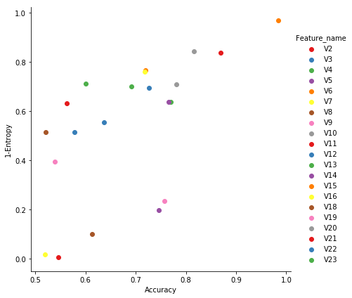

```python
g = sns.FacetGrid(summaryDf, hue="Feature_name",height=(6),palette="Set1")
g = (g.map(plt.scatter, "Accuracy", "1-Entropy").add_legend())
```

#### Summary : Looking above at the Accuracy v/s 1-Entropy a.k.a (Information gain) for each feature from V2 to V23 ,

- We can see that the best feature according to the plot is V6 as it has highest accuracy and highest information gain ~ 1 (Accuracy: 0.9847 , 1-Entropy:0.9697 , GINI-Index: 0.9704)
- This is also evident in the table above , where we can see that apart from accuracy and information gain aka 1-Entropy , the gini index as well is the highest for V6 feature , hence V6 is the best feature

# Q3 : NB and DT on MushroomDataSet

```python
print(mushroom_train[mushroom_train['V2']=='x'].shape[0])
print(mushroom_train.shape[0])
mushroom_train[mushroom_train['V2']=='x'][mushroom_train['V1']=='e'].shape[0]
print(mushroom_train.V2.nunique())
```

```
2210
4869
6
```

- As a pre-processing step , since we are dealing with letters here , we need to encode the letters so that the model can take digits produced out of the label encoder

```python
def encodeDataset(dataset):
    for col in dataset.columns:
        if dataset[col].dtype == type(object):
            labEncoder = preprocessing.LabelEncoder()
            dataset[col] = labEncoder.fit_transform(dataset[col])
    return dataset
```

```python
mushroom_train = encodeDataset(mushroom_train)
mushroom_test = encodeDataset(mushroom_test)

X_train = mushroom_train.iloc[:, 2:24].values
Y_train = mushroom_train.iloc[:, 1:2].values.ravel()

X_test  = mushroom_test.iloc[:, 2:24].values
Y_test = mushroom_test.iloc[:, 1:2].values.ravel()
```

```python
from sklearn.datasets import load_iris
from sklearn.model_selection import cross_val_score
from sklearn.tree import DecisionTreeClassifier


lambdaArray = []
size_Array = []

dec_score = []
dec_score_train = []
naive_score = []
naive_score_train = []

for lambdaVal in range(0,51,1):
    score = 0
    train_score=0
    lambdaArray.append(lambdaVal)
    naive = GaussianNB(var_smoothing = lambdaVal)
    naivemodel = naive.fit(X_train, Y_train)
    Y_pred = naivemodel.predict(X_test)
    train_score = round(metrics.accuracy_score(Y_train, naivemodel.predict(X_train)),4)
    score = round(metrics.accuracy_score(Y_test, Y_pred),4)
    naive_score.append(score)
    naive_score_train.append(train_score)


for size_thresh in range(4,65,4):
    score = 0
    train_score=0
    size_Array.append(size_thresh)
    decision_model = DecisionTreeClassifier(random_state=0,min_samples_split=size_thresh)
    model = decision_model.fit(X_train,Y_train)
    Y_pred = model.predict(X_test)
    train_score = round(metrics.accuracy_score(Y_train, decision_model.predict(X_train)),4)
    score = round(metrics.accuracy_score(Y_test, Y_pred),4)
    dec_score.append(score)
    dec_score_train.append(train_score)

dfNaive = pd.DataFrame({'lambda': lambdaArray , 'AccScore' : naive_score ,'Category' : 'Test' })
df_Naive_train = pd.DataFrame({'lambda': lambdaArray , 'AccScore' : naive_score_train ,'Category' : 'Train'})
dfNaive = pd.concat([dfNaive,df_Naive_train])

dfDec_Tree = pd.DataFrame({'size_thresh': size_Array , 'AccScore' : dec_score,'Category' : 'Test'})
dfDec_Tree_train = pd.DataFrame({'size_thresh': size_Array , 'AccScore' : dec_score_train,'Category' : 'Train'})
dfDec_Tree = pd.concat([dfDec_Tree,dfDec_Tree_train])
```

```python
dfNaive.sort_values(by='lambda').head(15)
```

|  | lambda | AccScore | Category |
| --- | --- | --- | --- |
| 0 | 0 | 0.516700 | Test |
| 0 | 0 | 0.518800 | Train |
| 1 | 1 | 0.811100 | Test |
| 1 | 1 | 0.830800 | Train |
| 2 | 2 | 0.798800 | Test |
| 2 | 2 | 0.820100 | Train |
| 3 | 3 | 0.787400 | Test |
| 3 | 3 | 0.811300 | Train |
| 4 | 4 | 0.774800 | Test |
| 4 | 4 | 0.798300 | Train |
| 5 | 5 | 0.781900 | Train |
| 5 | 5 | 0.765900 | Test |
| 6 | 6 | 0.758800 | Test |
| 6 | 6 | 0.768300 | Train |
| 7 | 7 | 0.754800 | Train |

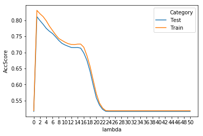

```python
ax = sns.lineplot(x="lambda", y="AccScore",hue="Category",data=dfNaive)
ax.set(xticks=np.arange(0,51,2))
```

```python
dfDec_Tree.sort_values(by='size_thresh').head(15)
```

|  | size_thresh | AccScore | Category |
| --- | --- | --- | --- |
| 0 | 4 | 1.000000 | Test |
| 0 | 4 | 1.000000 | Train |
| 1 | 8 | 1.000000 | Train |
| 1 | 8 | 1.000000 | Test |
| 2 | 12 | 1.000000 | Train |
| 2 | 12 | 1.000000 | Test |
| 3 | 16 | 1.000000 | Test |
| 3 | 16 | 1.000000 | Train |
| 4 | 20 | 1.000000 | Test |
| 4 | 20 | 1.000000 | Train |
| 5 | 24 | 0.997500 | Test |
| 5 | 24 | 0.999200 | Train |
| 6 | 28 | 0.996300 | Test |
| 6 | 28 | 0.996700 | Train |
| 7 | 32 | 0.996300 | Test |

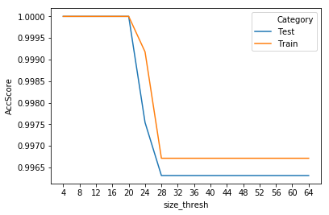

```python
ax = sns.lineplot(x="size_thresh", y="AccScore",hue="Category", data=dfDec_Tree)
ax.set(xticks=np.arange(4,65,4))
```

# Q4 : Bayesian on MNIST

- Q4 : rectify the dataset load and first row title as well check later
- Removed NA values from the dataframes

```python
mnist_dataset_train,mnist_dataset_test = readFiles('/Users/rajmati.marlecha/Desktop/Term3/DMG2/mnist/',False)
```

```
['.DS_Store', 'train6.csv', 'train7.csv', 'train5.csv', 'train4.csv', 'train0.csv', 'train1.csv', 'train3.csv', 'test8.csv', 'test9.csv', 'train2.csv', 'test4.csv', 'test5.csv', 'test7.csv', 'test6.csv', 'train9.csv', 'test2.csv', 'test3.csv', 'train8.csv', 'test1.csv', 'test0.csv']
     fileName  labelsTrain
0  train6.csv            6
1  train7.csv            7
2  train5.csv            5
3  train4.csv            4
4  train0.csv            0
    fileName  labelsTest
0  test8.csv           8
1  test9.csv           9
2  test4.csv           4
3  test5.csv           5
4  test7.csv           7
multi6
multi7
multi5
multi4
multi0
multi1
multi3
multi2
multi9
multi8
```

```python
print('Before')
print(mnist_dataset_train.Label.unique())
print(mnist_dataset_train.shape)
print(mnist_dataset_test.Label.unique())
print(mnist_dataset_test.shape)
print(mnist_dataset_train.columns[mnist_dataset_train.isna().any()].tolist())
print(mnist_dataset_test.columns[mnist_dataset_test.isna().any()].tolist())
mnist_dataset_train.dropna(inplace=True)
mnist_dataset_test.dropna(inplace=True)
print('After')
print(mnist_dataset_train.Label.unique())
print(mnist_dataset_train.shape)
print(mnist_dataset_test.Label.unique())
print(mnist_dataset_test.shape)
print(mnist_dataset_train.columns[mnist_dataset_train.isna().any()].tolist())
print(mnist_dataset_test.columns[mnist_dataset_test.isna().any()].tolist())
mnist_dataset_train.tail()
```

```
Before
[6 7 5 4 0 1 3 2 9 8]
(36241, 786)
[8 9 4 5 7 6 2 3 1 0]
(24419, 786)
[0, 1, 2, 3, 4, 5, 6, 7, 8, 9, 10, 11, 12, 13, 14, 15, 16, 17, 18, 19, 20, 21, 22, 23, 24, 25, 26, 27, 28, 29, 30, 31, 32, 33, 34, 35, 36, 37, 38, 39, 40, 41, 42, 43, 44, 45, 46, 47, 48, 49, 50, 51, 52, 53, 54, 55, 56, 57, 58, 59, 60, 61, 62, 63, 64, 65, 66, 67, 68, 69, 70, 71, 72, 73, 74, 75, 76, 7…
[0, 1, 2, 3, 4, 5, 6, 7, 8, 9, 10, 11, 12, 13, 14, 15, 16, 17, 18, 19, 20, 21, 22, 23, 24, 25, 26, 27, 28, 29, 30, 31, 32, 33, 34, 35, 36, 37, 38, 39, 40, 41, 42, 43, 44, 45, 46, 47, 48, 49, 50, 51, 52, 53, 54, 55, 56, 57, 58, 59, 60, 61, 62, 63, 64, 65, 66, 67, 68, 69, 70, 71, 72, 73, 74, 75, 76, 7…
After
[6 7 5 4 0 1 3 2 9 8]
(35847, 786)
[8 9 4 5 7 6 2 3 1 0]
(24153, 786)
[]
[]
```

|  | 0 | 1 | 2 | 3 | 4 | 5 | 6 | 7 | 8 | 9 | 10 | 11 | 12 | 13 | 14 | 15 | 16 | 17 | 18 | 19 | 20 | 21 | 22 | 23 | 24 | 25 | 26 | 27 | 28 | … |
| --- | --- | --- | --- | --- | --- | --- | --- | --- | --- | --- | --- | --- | --- | --- | --- | --- | --- | --- | --- | --- | --- | --- | --- | --- | --- | --- | --- | --- | --- | --- |
| 3491 | 5842 | 0.000000 | 0.000000 | 0.000000 | 0.000000 | 0.000000 | 0.000000 | 0.000000 | 0.000000 | 0.000000 | 0.000000 | 0.000000 | 0.000000 | 0.000000 | 0.000000 | 0.000000 | 0.000000 | 0.000000 | 0.000000 | 0.000000 | 0.000000 | 0.000000 | 0.000000 | 0.000000 | 0.000000 | 0.000000 | 0.000000 | 0.000000 | 0.000000 | … |
| 3492 | 5844 | 0.000000 | 0.000000 | 0.000000 | 0.000000 | 0.000000 | 0.000000 | 0.000000 | 0.000000 | 0.000000 | 0.000000 | 0.000000 | 0.000000 | 0.000000 | 0.000000 | 0.000000 | 0.000000 | 0.000000 | 0.000000 | 0.000000 | 0.000000 | 0.000000 | 0.000000 | 0.000000 | 0.000000 | 0.000000 | 0.000000 | 0.000000 | 0.000000 | … |
| 3493 | 5845 | 0.000000 | 0.000000 | 0.000000 | 0.000000 | 0.000000 | 0.000000 | 0.000000 | 0.000000 | 0.000000 | 0.000000 | 0.000000 | 0.000000 | 0.000000 | 0.000000 | 0.000000 | 0.000000 | 0.000000 | 0.000000 | 0.000000 | 0.000000 | 0.000000 | 0.000000 | 0.000000 | 0.000000 | 0.000000 | 0.000000 | 0.000000 | 0.000000 | … |
| 3494 | 5847 | 0.000000 | 0.000000 | 0.000000 | 0.000000 | 0.000000 | 0.000000 | 0.000000 | 0.000000 | 0.000000 | 0.000000 | 0.000000 | 0.000000 | 0.000000 | 0.000000 | 0.000000 | 0.000000 | 0.000000 | 0.000000 | 0.000000 | 0.000000 | 0.000000 | 0.000000 | 0.000000 | 0.000000 | 0.000000 | 0.000000 | 0.000000 | 0.000000 | … |
| 3495 | 5849 | 0.000000 | 0.000000 | 0.000000 | 0.000000 | 0.000000 | 0.000000 | 0.000000 | 0.000000 | 0.000000 | 0.000000 | 0.000000 | 0.000000 | 0.000000 | 0.000000 | 0.000000 | 0.000000 | 0.000000 | 0.000000 | 0.000000 | 0.000000 | 0.000000 | 0.000000 | 0.000000 | 0.000000 | 0.000000 | 0.000000 | 0.000000 | 0.000000 | … |

```python
mnist_dataset_train.info()
```

```
<class 'pandas.core.frame.DataFrame'>
Int64Index: 35847 entries, 0 to 3495
Columns: 786 entries, 0 to Label
dtypes: float64(784), int64(1), object(1)
memory usage: 215.2+ MB
```

```python
sc = StandardScaler()

X_train = mnist_dataset_train.iloc[:, 1:785].values
all_Y_train = mnist_dataset_train.iloc[:,-1].values.ravel()

X_train = sc.fit_transform(X_train)

pca = PCA(n_components = 9)

X_test = mnist_dataset_test.iloc[:, 1:785].values
all_Y_test = mnist_dataset_test.iloc[:, -1].values.ravel()

X_test = sc.fit_transform(X_test)

D1_dataset_array_train = pca.fit_transform(X_train)
D1_dataset_train =pd.DataFrame(D1_dataset_array_train)


D1_dataset_array_test = pca.transform(X_test)
D1_dataset_test =pd.DataFrame(D1_dataset_array_test)
```

```python
lda = LinearDiscriminantAnalysis(n_components = 9)
D2_dataset_array_train = lda.fit_transform(X_train, all_Y_train)
D2_dataset_train =pd.DataFrame(D2_dataset_array_train)

D2_dataset_array_test = lda.transform(X_test)
D2_dataset_test =pd.DataFrame(D2_dataset_array_test)

D2_dataset_train.head()
```

|  | 0 | 1 | 2 | 3 | 4 | 5 | 6 | 7 | 8 |
| --- | --- | --- | --- | --- | --- | --- | --- | --- | --- |
| 0 | -1.946813 | -0.632781 | 3.874053 | -0.530854 | 1.038882 | 0.906426 | -0.126411 | -0.267074 | -0.372740 |
| 1 | -1.522271 | -0.611522 | 2.063381 | -0.331797 | 0.480179 | 1.456358 | 0.589032 | 0.226154 | -0.195311 |
| 2 | -2.466529 | 1.187411 | 4.149887 | -0.432711 | -0.998940 | 1.078628 | -0.209891 | -0.107586 | -0.852970 |
| 3 | -2.965549 | -0.370041 | 2.419975 | 1.021362 | -0.073248 | 0.667172 | -1.205725 | -0.339049 | -0.181532 |
| 4 | -3.296043 | 0.496587 | 4.854694 | -1.500546 | 1.706597 | 1.963814 | -0.869601 | -1.699896 | 0.263691 |

```python
all_Y_train.dtype
```

```
dtype('int64')
```

```python
model_1_D1 = NaiveBayes.from_samples(NormalDistribution, D1_dataset_train,all_Y_train)
#fit_model_1_D1 = model_1_D1.fit(D1_dataset_train, Y_train)

model_2_D1 = BayesClassifier.from_samples(MultivariateGaussianDistribution, D1_dataset_train, all_Y_train)
#fit_model_2_D1 = model_2_D1.fit(D1_dataset_train, Y_train)

model_1_D2 = NaiveBayes.from_samples(NormalDistribution, D2_dataset_train, all_Y_train)
model_2_D2 = BayesClassifier.from_samples(MultivariateGaussianDistribution, D2_dataset_train, all_Y_train)

Y_pred_model_1_D1 = model_1_D1.predict(D1_dataset_test)
score_model_1_D1 = round(metrics.accuracy_score(all_Y_test, Y_pred_model_1_D1),4)

Y_pred_model_2_D1 = model_2_D1.predict(D1_dataset_test)
score_model_2_D1 = round(metrics.accuracy_score(all_Y_test, Y_pred_model_2_D1),4)

Y_pred_model_1_D2 = model_1_D2.predict(D2_dataset_test)
score_model_1_D2 = round(metrics.accuracy_score(all_Y_test, Y_pred_model_1_D2),4)

Y_pred_model_2_D2 = model_2_D2.predict(D2_dataset_test)
score_model_2_D2 = round(metrics.accuracy_score(all_Y_test, Y_pred_model_2_D2),4)

data = [['model_1_D1','Diag',score_model_1_D1],['model_2_D1','Full',score_model_2_D1],['model_1_D2','Diag',score_model_1_D2],['model_2_D2','Full',score_model_2_D2] ]
dftoCompare = pd.DataFrame(data,columns = ['Model','TypeofCov',"Test Accuracy Score"])
dftoCompare
```

|  | Model | TypeofCov | Test Accuracy Score |
| --- | --- | --- | --- |
| 0 | model_1_D1 | Diag | 0.752800 |
| 1 | model_2_D1 | Full | 0.840700 |
| 2 | model_1_D2 | Diag | 0.870600 |
| 3 | model_2_D2 | Full | 0.883300 |

#### Summary :

# Q5 : knn and Parzen on MNIST

```python
def buildParzenClassifierModel(sigma,classVal,X_train,Y_train):
    X_train_Copy = X_train.copy()
    X_train_Copy["Label"] = Y_train
    X_train_subset = X_train_Copy[X_train_Copy.Label == classVal]
    parzenmodel = KernelDensity(bandwidth=sigma).fit(X_train_subset)
    logprior = np.log(X_train_subset.shape[0] / X_train.shape[0])
    return parzenmodel,logprior,X_train_Copy

def buildEntireModel(sigma,X_train,Y_train):
    models =[]
    logpriors =[]
    priormodel = ''
    for classVal in np.sort(np.unique(all_Y_train)):
        parzenmodel,logprior,X_train_Copy = buildParzenClassifierModel(sigma,classVal,X_train,Y_train)
        logpriors.append(logprior)
        models.append(parzenmodel)
    return models,logpriors

def predict(X,Y,distinctClasses):
    X_train_pred = X.copy()
    X_train_pred["Label"] = Y
    probabs = np.vstack([model.score_samples(X_train_pred) for model in models]).T
    expprobabs = np.exp(probabs + logpriors)
    pred_prob = expprobabs / expprobabs.sum(1, keepdims=True)
    return distinctClasses[np.argmax(pred_prob, 1)]
```

```python
kArray = []
sigma_Array = []

knn_score = []
knn_score_train = []
parzen_score = []
parzen_score_train = []

for k in range(1,19,2):
    print(k)
    score = 0
    train_score = 0
    kArray.append(k)
    knn = KNeighborsClassifier(n_neighbors=k)
    knnmodel = knn.fit(D1_dataset_train, all_Y_train)
    Y_pred = knnmodel.predict(D1_dataset_test)
    train_score = round(metrics.accuracy_score(all_Y_train, knnmodel.predict(D1_dataset_train)),4)
    score = round(metrics.accuracy_score(all_Y_test, Y_pred),4)
    knn_score_train.append(train_score)
    knn_score.append(score)


distinctClasses= np.sort(np.unique(all_Y_train))
for sigma in np.arange(0.1,3.1,0.1):
    print(sigma)
    score = 0
    train_score = 0
    models =[]
    logpriors =[]
    models,logpriors= buildEntireModel(sigma,D1_dataset_train,all_Y_train)
    sigma_Array.append(sigma)
    train_score = round(metrics.accuracy_score(all_Y_train, predict(D1_dataset_train,all_Y_train,distinctClasses)),4)
    score = round(metrics.accuracy_score(all_Y_test, predict(D1_dataset_test,all_Y_test,distinctClasses)),4)
    parzen_score.append(score)
    parzen_score_train.append(train_score)

dfKnn = pd.DataFrame({'k': kArray , 'AccScore' : knn_score, 'Category' : 'Test'})
dfKnn_Train = pd.DataFrame({'k': kArray , 'AccScore' : knn_score_train, 'Category' : 'Train'})
dfKnn = pd.concat([dfKnn,dfKnn_Train])

dfParzen= pd.DataFrame({'sigma': sigma_Array , 'AccScore' : parzen_score , 'Category' : 'Test'})
dfParzen_Train= pd.DataFrame({'sigma': sigma_Array , 'AccScore' : parzen_score_train , 'Category' : 'Train'})
dfParzen = pd.concat([dfParzen,dfParzen_Train])
```

```
1
3
5
7
9
11
13
15
17
0.1
0.2
0.30000000000000004
0.4
0.5
0.6
0.7000000000000001
0.8
0.9
1.0
1.1
1.2000000000000002
1.3000000000000003
1.4000000000000001
1.5000000000000002
1.6
1.7000000000000002
1.8000000000000003
1.9000000000000001
2.0
2.1
2.2
2.3000000000000003
2.4000000000000004
2.5000000000000004
2.6
2.7
2.8000000000000003
2.9000000000000004
3.0000000000000004
```

```python
dfKnn.sort_values(by='k').head(15)
```

|  | k | AccScore | Category |
| --- | --- | --- | --- |
| 0 | 1 | 0.863100 | Test |
| 0 | 1 | 1.000000 | Train |
| 1 | 3 | 0.879100 | Test |
| 1 | 3 | 0.933300 | Train |
| 2 | 5 | 0.885100 | Test |
| 2 | 5 | 0.921200 | Train |
| 3 | 7 | 0.886000 | Test |
| 3 | 7 | 0.915100 | Train |
| 4 | 9 | 0.888000 | Test |
| 4 | 9 | 0.910200 | Train |
| 5 | 11 | 0.887100 | Test |
| 5 | 11 | 0.906800 | Train |
| 6 | 13 | 0.886600 | Test |
| 6 | 13 | 0.903400 | Train |
| 7 | 15 | 0.886400 | Test |

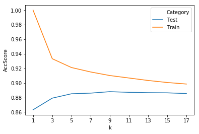

```python
ax = sns.lineplot(x="k", y="AccScore",hue='Category', data=dfKnn)
ax.set(xticks=np.arange(1,19,2))
```

```python
dfParzen.sort_values(by='sigma').head(20)
```

|  | sigma | AccScore | Category |
| --- | --- | --- | --- |
| 0 | 0.100000 | 0.690100 | Test |
| 0 | 0.100000 | 1.000000 | Train |
| 1 | 0.200000 | 0.753100 | Test |
| 1 | 0.200000 | 1.000000 | Train |
| 2 | 0.300000 | 0.806300 | Test |
| 2 | 0.300000 | 1.000000 | Train |
| 3 | 0.400000 | 0.871000 | Test |
| 3 | 0.400000 | 1.000000 | Train |
| 4 | 0.500000 | 0.914000 | Test |
| 4 | 0.500000 | 1.000000 | Train |
| 5 | 0.600000 | 1.000000 | Train |
| 5 | 0.600000 | 0.938600 | Test |
| 6 | 0.700000 | 1.000000 | Train |
| 6 | 0.700000 | 0.950600 | Test |
| 7 | 0.800000 | 1.000000 | Train |
| 7 | 0.800000 | 0.958100 | Test |
| 8 | 0.900000 | 0.960300 | Test |
| 8 | 0.900000 | 1.000000 | Train |
| 9 | 1.000000 | 0.999900 | Train |
| 9 | 1.000000 | 0.961200 | Test |

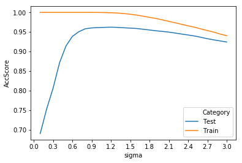

```python
ax = sns.lineplot(x="sigma", y="AccScore",hue='Category', data=dfParzen)
ax.set(xticks=np.arange(0,3.1,0.3))
```

```python
#on D2 dataset
kArray = []
sigma_Array = []

knn_score = []
knn_score_train = []
parzen_score = []
parzen_score_train = []

for k in range(1,19,2):
    print(k)
    score = 0
    train_score = 0
    kArray.append(k)
    knn = KNeighborsClassifier(n_neighbors=k)
    knnmodel = knn.fit(D2_dataset_train, all_Y_train)
    Y_pred = knnmodel.predict(D2_dataset_test)
    train_score = round(metrics.accuracy_score(all_Y_train, knnmodel.predict(D2_dataset_train)),4)
    score = round(metrics.accuracy_score(all_Y_test, Y_pred),4)
    knn_score_train.append(train_score)
    knn_score.append(score)


distinctClasses= np.sort(np.unique(all_Y_train))
for sigma in np.arange(0.1,3.1,0.1):
    print(sigma)
    score = 0
    train_score = 0
    models =[]
    logpriors =[]
    models,logpriors= buildEntireModel(sigma,D2_dataset_train,all_Y_train)
    sigma_Array.append(sigma)
    train_score = round(metrics.accuracy_score(all_Y_train, predict(D2_dataset_train,all_Y_train,distinctClasses)),4)
    score = round(metrics.accuracy_score(all_Y_test, predict(D2_dataset_test,all_Y_test,distinctClasses)),4)
    parzen_score.append(score)
    parzen_score_train.append(train_score)
```

```
1
3
5
7
9
11
13
15
17
0.1
0.2
0.30000000000000004
0.4
0.5
0.6
0.7000000000000001
0.8
0.9
1.0
1.1
1.2000000000000002
1.3000000000000003
1.4000000000000001
1.5000000000000002
1.6
1.7000000000000002
1.8000000000000003
1.9000000000000001
2.0
2.1
2.2
2.3000000000000003
2.4000000000000004
2.5000000000000004
2.6
2.7
2.8000000000000003
2.9000000000000004
3.0000000000000004
```

```python
dfKnn_D2 = pd.DataFrame({'k': kArray , 'AccScore' : knn_score, 'Category' : 'Test'})
dfKnn_Train = pd.DataFrame({'k': kArray , 'AccScore' : knn_score_train, 'Category' : 'Train'})
dfKnn_D2 = pd.concat([dfKnn_D2,dfKnn_Train])

dfParzen_D2= pd.DataFrame({'sigma': sigma_Array , 'AccScore' : parzen_score , 'Category' : 'Test'})
dfParzen_Train= pd.DataFrame({'sigma': sigma_Array , 'AccScore' : parzen_score_train , 'Category' : 'Train'})
dfParzen_D2 = pd.concat([dfParzen_D2,dfParzen_Train])
```

```python
dfKnn_D2.sort_values(by='k').head(15)
```

|  | k | AccScore | Category |
| --- | --- | --- | --- |
| 0 | 1 | 0.891300 | Test |
| 0 | 1 | 1.000000 | Train |
| 1 | 3 | 0.904400 | Test |
| 1 | 3 | 0.948000 | Train |
| 2 | 5 | 0.910100 | Test |
| 2 | 5 | 0.939600 | Train |
| 3 | 7 | 0.910500 | Test |
| 3 | 7 | 0.935100 | Train |
| 4 | 9 | 0.911000 | Test |
| 4 | 9 | 0.933800 | Train |
| 5 | 11 | 0.910400 | Test |
| 5 | 11 | 0.930900 | Train |
| 6 | 13 | 0.909800 | Test |
| 6 | 13 | 0.929500 | Train |
| 7 | 15 | 0.908900 | Test |

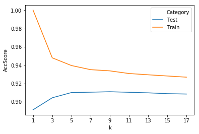

```python
ax = sns.lineplot(x="k", y="AccScore",hue='Category', data=dfKnn_D2)
ax.set(xticks=np.arange(1,19,2))
```

```python
dfParzen_D2.sort_values(by='sigma').head(20)
```

|  | sigma | AccScore | Category |
| --- | --- | --- | --- |
| 0 | 0.100000 | 0.927000 | Test |
| 0 | 0.100000 | 1.000000 | Train |
| 1 | 0.200000 | 0.972000 | Test |
| 1 | 0.200000 | 1.000000 | Train |
| 2 | 0.300000 | 0.985200 | Test |
| 2 | 0.300000 | 1.000000 | Train |
| 3 | 0.400000 | 0.986500 | Test |
| 3 | 0.400000 | 1.000000 | Train |
| 4 | 0.500000 | 0.986700 | Test |
| 4 | 0.500000 | 0.999900 | Train |
| 5 | 0.600000 | 0.999600 | Train |
| 5 | 0.600000 | 0.986000 | Test |
| 6 | 0.700000 | 0.998100 | Train |
| 6 | 0.700000 | 0.984600 | Test |
| 7 | 0.800000 | 0.995300 | Train |
| 7 | 0.800000 | 0.982200 | Test |
| 8 | 0.900000 | 0.979300 | Test |
| 8 | 0.900000 | 0.991300 | Train |
| 9 | 1.000000 | 0.985400 | Train |
| 9 | 1.000000 | 0.975600 | Test |

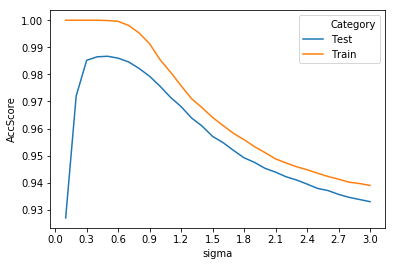

```python
ax = sns.lineplot(x="sigma", y="AccScore",hue='Category', data=dfParzen_D2)
ax.set(xticks=np.arange(0,3.1,0.3))
```

### Q7 : Pairwise classifier features

```python
mnist_dataset_train,mnist_dataset_test = readFiles('/Users/rajmati.marlecha/Desktop/Term3/DMG2/mnist/',False)
```

```
['.DS_Store', 'train6.csv', 'train7.csv', 'train5.csv', 'train4.csv', 'train0.csv', 'train1.csv', 'train3.csv', 'test8.csv', 'test9.csv', 'train2.csv', 'test4.csv', 'test5.csv', 'test7.csv', 'test6.csv', 'train9.csv', 'test2.csv', 'test3.csv', 'train8.csv', 'test1.csv', 'test0.csv']
     fileName  labelsTrain
0  train6.csv            6
1  train7.csv            7
2  train5.csv            5
3  train4.csv            4
4  train0.csv            0
    fileName  labelsTest
0  test8.csv           8
1  test9.csv           9
2  test4.csv           4
3  test5.csv           5
4  test7.csv           7
multi6
multi7
multi5
multi4
multi0
multi1
multi3
multi2
multi9
multi8
```

```python
print('Before')
print(mnist_dataset_train.Label.unique())
print(mnist_dataset_train.shape)
print(mnist_dataset_test.Label.unique())
print(mnist_dataset_test.shape)
print(mnist_dataset_train.columns[mnist_dataset_train.isna().any()].tolist())
print(mnist_dataset_test.columns[mnist_dataset_test.isna().any()].tolist())
mnist_dataset_train.dropna(inplace=True)
mnist_dataset_test.dropna(inplace=True)
print('After')
print(mnist_dataset_train.Label.unique())
print(mnist_dataset_train.shape)
print(mnist_dataset_test.Label.unique())
print(mnist_dataset_test.shape)
print(mnist_dataset_train.columns[mnist_dataset_train.isna().any()].tolist())
print(mnist_dataset_test.columns[mnist_dataset_test.isna().any()].tolist())
mnist_dataset_train.tail()
```

```
Before
[6 7 5 4 0 1 3 2 9 8]
(36241, 786)
[8 9 4 5 7 6 2 3 1 0]
(24419, 786)
[0, 1, 2, 3, 4, 5, 6, 7, 8, 9, 10, 11, 12, 13, 14, 15, 16, 17, 18, 19, 20, 21, 22, 23, 24, 25, 26, 27, 28, 29, 30, 31, 32, 33, 34, 35, 36, 37, 38, 39, 40, 41, 42, 43, 44, 45, 46, 47, 48, 49, 50, 51, 52, 53, 54, 55, 56, 57, 58, 59, 60, 61, 62, 63, 64, 65, 66, 67, 68, 69, 70, 71, 72, 73, 74, 75, 76, 7…
[0, 1, 2, 3, 4, 5, 6, 7, 8, 9, 10, 11, 12, 13, 14, 15, 16, 17, 18, 19, 20, 21, 22, 23, 24, 25, 26, 27, 28, 29, 30, 31, 32, 33, 34, 35, 36, 37, 38, 39, 40, 41, 42, 43, 44, 45, 46, 47, 48, 49, 50, 51, 52, 53, 54, 55, 56, 57, 58, 59, 60, 61, 62, 63, 64, 65, 66, 67, 68, 69, 70, 71, 72, 73, 74, 75, 76, 7…
After
[6 7 5 4 0 1 3 2 9 8]
(35847, 786)
[8 9 4 5 7 6 2 3 1 0]
(24153, 786)
[]
[]
```

|  | 0 | 1 | 2 | 3 | 4 | 5 | 6 | 7 | 8 | 9 | 10 | 11 | 12 | 13 | 14 | 15 | 16 | 17 | 18 | 19 | 20 | 21 | 22 | 23 | 24 | 25 | 26 | 27 | 28 | … |
| --- | --- | --- | --- | --- | --- | --- | --- | --- | --- | --- | --- | --- | --- | --- | --- | --- | --- | --- | --- | --- | --- | --- | --- | --- | --- | --- | --- | --- | --- | --- |
| 3491 | 5842 | 0.000000 | 0.000000 | 0.000000 | 0.000000 | 0.000000 | 0.000000 | 0.000000 | 0.000000 | 0.000000 | 0.000000 | 0.000000 | 0.000000 | 0.000000 | 0.000000 | 0.000000 | 0.000000 | 0.000000 | 0.000000 | 0.000000 | 0.000000 | 0.000000 | 0.000000 | 0.000000 | 0.000000 | 0.000000 | 0.000000 | 0.000000 | 0.000000 | … |
| 3492 | 5844 | 0.000000 | 0.000000 | 0.000000 | 0.000000 | 0.000000 | 0.000000 | 0.000000 | 0.000000 | 0.000000 | 0.000000 | 0.000000 | 0.000000 | 0.000000 | 0.000000 | 0.000000 | 0.000000 | 0.000000 | 0.000000 | 0.000000 | 0.000000 | 0.000000 | 0.000000 | 0.000000 | 0.000000 | 0.000000 | 0.000000 | 0.000000 | 0.000000 | … |
| 3493 | 5845 | 0.000000 | 0.000000 | 0.000000 | 0.000000 | 0.000000 | 0.000000 | 0.000000 | 0.000000 | 0.000000 | 0.000000 | 0.000000 | 0.000000 | 0.000000 | 0.000000 | 0.000000 | 0.000000 | 0.000000 | 0.000000 | 0.000000 | 0.000000 | 0.000000 | 0.000000 | 0.000000 | 0.000000 | 0.000000 | 0.000000 | 0.000000 | 0.000000 | … |
| 3494 | 5847 | 0.000000 | 0.000000 | 0.000000 | 0.000000 | 0.000000 | 0.000000 | 0.000000 | 0.000000 | 0.000000 | 0.000000 | 0.000000 | 0.000000 | 0.000000 | 0.000000 | 0.000000 | 0.000000 | 0.000000 | 0.000000 | 0.000000 | 0.000000 | 0.000000 | 0.000000 | 0.000000 | 0.000000 | 0.000000 | 0.000000 | 0.000000 | 0.000000 | … |
| 3495 | 5849 | 0.000000 | 0.000000 | 0.000000 | 0.000000 | 0.000000 | 0.000000 | 0.000000 | 0.000000 | 0.000000 | 0.000000 | 0.000000 | 0.000000 | 0.000000 | 0.000000 | 0.000000 | 0.000000 | 0.000000 | 0.000000 | 0.000000 | 0.000000 | 0.000000 | 0.000000 | 0.000000 | 0.000000 | 0.000000 | 0.000000 | 0.000000 | 0.000000 | … |

```python
# this method provide the indexes to be used to seperates the dataset that needs to be passed to LDA and not
# this checks for the columns having sum of variance across the classes as zero to remove them before LDA so that we could
#avoid errors or hinderance of those pixels while modelling
def getZeroNonZeroVarianceIndexes(dataset,label1,label2):
    #print(dataset.columns)
    dataset = dataset.iloc[:,1:786]
    #print(dataset.columns)
    newdf = dataset[dataset['Label']==label1].var(axis=0)
    newdf1 = dataset[dataset['Label']==label2].var(axis=0)
    newdf3 = newdf + newdf1
    return list(newdf3[newdf3==0].index),list(newdf3[newdf3!=0].index)
```

```python
# this method divides the master dataset to a subset corresponding to labels provided
from sklearn.preprocessing import StandardScaler
from sklearn.preprocessing import Normalizer
def defineSubsetsforLDA(label1,label2,isDimsRemoved=False,listNonZero=[]):

    listNonZero.append("Label")

    if(isDimsRemoved):
        datasetTrain = mnist_dataset_train.loc[:,listNonZero]
        datasetTest =  mnist_dataset_test.loc[:,listNonZero]
    else:
        datasetTrain = mnist_dataset_train
        datasetTest = mnist_dataset_test

    X_train = datasetTrain[datasetTrain['Label'].isin([label1,label2])].iloc[:, 1:785].values
    #sc = Normalizer()
    #X_train = sc.fit_transform(X_train)
    Y_train = datasetTrain[datasetTrain['Label'].isin([label1,label2])].iloc[:,-1].values.ravel()
    print(Y_train)
    X_test = datasetTest[datasetTest['Label'].isin([label1,label2])].iloc[:, 1:785].values
    #X_test = sc.fit_transform(X_test)
    Y_test = datasetTest[datasetTest['Label'].isin([label1,label2])].iloc[:, -1].values.ravel()

    return X_train,Y_train,X_test,Y_test
```

```python
from matplotlib import pyplot as plt # referred DLIOT class tutorial material here
import numpy as np
def createImage(imageArray):
    two_d = (np.reshape(imageArray, (28, 28)) * 255).astype(np.uint8)
    plt.imshow(two_d)
    return plt
```

```python
def performLDA(comps,X_train,Y_train,X_test,Y_test): # this method gives the scalings vector which is
    lda = LinearDiscriminantAnalysis(n_components = comps)
    dataset_array_train = lda.fit(X_train, Y_train).scalings_
    dataset_array_test = lda.fit(X_test, Y_test).scalings_
    return dataset_array_train,dataset_array_test
```

```python
mnist_dataset_train.head()
```

|  | 0 | 1 | 2 | 3 | 4 | 5 | 6 | 7 | 8 | 9 | 10 | 11 | 12 | 13 | 14 | 15 | 16 | 17 | 18 | 19 | 20 | 21 | 22 | 23 | 24 | 25 | 26 | 27 | 28 | … |
| --- | --- | --- | --- | --- | --- | --- | --- | --- | --- | --- | --- | --- | --- | --- | --- | --- | --- | --- | --- | --- | --- | --- | --- | --- | --- | --- | --- | --- | --- | --- |
| 0 | 1 | 0.000000 | 0.000000 | 0.000000 | 0.000000 | 0.000000 | 0.000000 | 0.000000 | 0.000000 | 0.000000 | 0.000000 | 0.000000 | 0.000000 | 0.000000 | 0.000000 | 0.000000 | 0.000000 | 0.000000 | 0.000000 | 0.000000 | 0.000000 | 0.000000 | 0.000000 | 0.000000 | 0.000000 | 0.000000 | 0.000000 | 0.000000 | 0.000000 | … |
| 1 | 2 | 0.000000 | 0.000000 | 0.000000 | 0.000000 | 0.000000 | 0.000000 | 0.000000 | 0.000000 | 0.000000 | 0.000000 | 0.000000 | 0.000000 | 0.000000 | 0.000000 | 0.000000 | 0.000000 | 0.000000 | 0.000000 | 0.000000 | 0.000000 | 0.000000 | 0.000000 | 0.000000 | 0.000000 | 0.000000 | 0.000000 | 0.000000 | 0.000000 | … |
| 2 | 4 | 0.000000 | 0.000000 | 0.000000 | 0.000000 | 0.000000 | 0.000000 | 0.000000 | 0.000000 | 0.000000 | 0.000000 | 0.000000 | 0.000000 | 0.000000 | 0.000000 | 0.000000 | 0.000000 | 0.000000 | 0.000000 | 0.000000 | 0.000000 | 0.000000 | 0.000000 | 0.000000 | 0.000000 | 0.000000 | 0.000000 | 0.000000 | 0.000000 | … |
| 3 | 6 | 0.000000 | 0.000000 | 0.000000 | 0.000000 | 0.000000 | 0.000000 | 0.000000 | 0.000000 | 0.000000 | 0.000000 | 0.000000 | 0.000000 | 0.000000 | 0.000000 | 0.000000 | 0.000000 | 0.000000 | 0.000000 | 0.000000 | 0.000000 | 0.000000 | 0.000000 | 0.000000 | 0.000000 | 0.000000 | 0.000000 | 0.000000 | 0.000000 | … |
| 4 | 8 | 0.000000 | 0.000000 | 0.000000 | 0.000000 | 0.000000 | 0.000000 | 0.000000 | 0.000000 | 0.000000 | 0.000000 | 0.000000 | 0.000000 | 0.000000 | 0.000000 | 0.000000 | 0.000000 | 0.000000 | 0.000000 | 0.000000 | 0.000000 | 0.000000 | 0.000000 | 0.000000 | 0.000000 | 0.000000 | 0.000000 | 0.000000 | 0.000000 | … |

```
[0 1 2 3 4 5 6 7 8 9]
0 1
Image plot post LDA Between digits : 0 and 1
[0 0 0 ... 1 1 1]
(7572, 589)
```

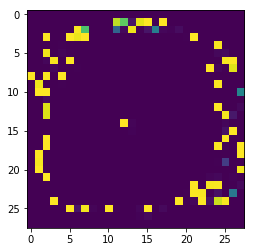

```
0 2
Image plot post LDA Between digits : 0 and 2
[0 0 0 ... 2 2 2]
(7089, 596)
```

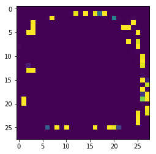

```
0 3
Image plot post LDA Between digits : 0 and 3
[0 0 0 ... 3 3 3]
(7208, 610)
```

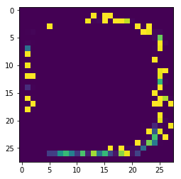

```
0 4
Image plot post LDA Between digits : 0 and 4
[4 4 4 ... 0 0 0]
(7028, 604)
```

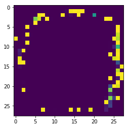

```
0 5
Image plot post LDA Between digits : 0 and 5
[5 5 5 ... 0 0 0]
(6764, 603)
```

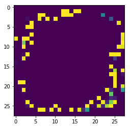

```
0 6
Image plot post LDA Between digits : 0 and 6
[6 6 6 ... 0 0 0]
(7070, 596)
```

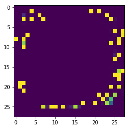

```
0 7
Image plot post LDA Between digits : 0 and 7
[7 7 7 ... 0 0 0]
(7287, 632)
```

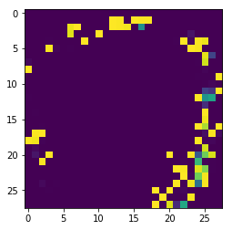

```
0 8
Image plot post LDA Between digits : 0 and 8
[0 0 0 ... 8 8 8]
(7032, 589)
```

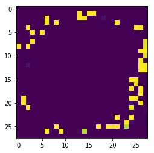

```
0 9
Image plot post LDA Between digits : 0 and 9
[0 0 0 ... 9 9 9]
(7085, 598)
```

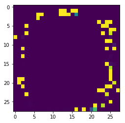

```
1 2
Image plot post LDA Between digits : 1 and 2
[1 1 1 ... 2 2 2]
(7589, 608)
```

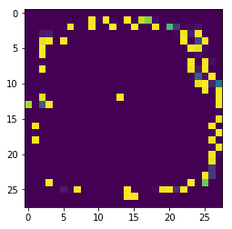

```
1 3
Image plot post LDA Between digits : 1 and 3
[1 1 1 ... 3 3 3]
(7708, 607)
```

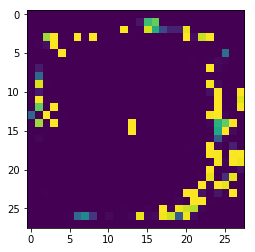

```
1 4
Image plot post LDA Between digits : 1 and 4
[4 4 4 ... 1 1 1]
(7528, 608)
```

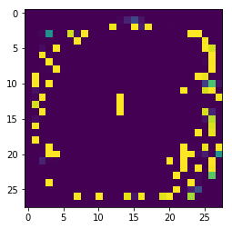

```
1 5
Image plot post LDA Between digits : 1 and 5
[5 5 5 ... 1 1 1]
(7264, 609)
```

[33 more figures not shown]

```python
import itertools
imgArray =[]
oldColSeq = list(mnist_dataset_train.iloc[1:2,1:786].columns.values)
if 'Label' in oldColSeq: oldColSeq.remove('Label')

my_list = numpy.unique(mnist_dataset_train.Label)
print(my_list)
for pair in itertools.combinations(my_list, r=2):
    print(*pair)
    print("Image plot post LDA Between digits : " + str(pair[0]) + " and " + str(pair[1]))
    lstZero,lstNonZero = getZeroNonZeroVarianceIndexes(mnist_dataset_train,pair[0],pair[1])
    X_train_img,Y_train_img,X_test_img,Y_test_img = defineSubsetsforLDA(pair[0],pair[1],True,lstNonZero)
    print(X_train_img.shape)
    dataset_array_train_img,dataset_array_test_img = performLDA(1,X_train_img,Y_train_img,X_test_img,Y_test_img)

    if 'Label' in lstZero: lstZero.remove('Label')
    if 'Label' in lstNonZero: lstNonZero.remove('Label')


    zeroListData = numpy.zeros(shape=(1,len(lstZero)))
    df = pd.DataFrame(zeroListData,columns=lstZero)

    imageDF = pd.DataFrame(dataset_array_train_img.transpose(),columns=lstNonZero)
    imageDF = pd.concat([imageDF,df],axis=1)
    imageDF = imageDF[oldColSeq]
    createImage(imageDF.values).show()
```

- Looking at the pixels we can see :
  - For digit 1 when compared with all others , the center pixel is higlighted,
    - That center pixel further gets elongated for digits 6 , 5 , 4 and 3
  - Similarly for digit 6 with all other pairs we can see that the top portion of the pixels that make a zero are not highlighted
  - Same way for digit 2 the left bottom pixels dont highlight rest do
  - For pair 6 and 2 , both of them are missing.
  - For pair 3 and 6 the bottom pixels show overlap with differnt color (greenish )
  - For pair 4 and 7 we can see that there is a pixel that has greenish color on the top right , this is the place of overlap too.
    - These pattern follows for the rest of the digits too and hence we can infer that where there is an overlap there might be a possibility of lower prediction power of the model as it cannot differentiate them

#### Question 8 : Binary hierarchical classifier

```python
mnist_dataset_train,mnist_dataset_test = readFiles('/Users/rajmati.marlecha/Desktop/Term3/DMG2/mnist/',False)
```

```
['.DS_Store', 'train6.csv', 'train7.csv', 'train5.csv', 'train4.csv', 'train0.csv', 'train1.csv', 'train3.csv', 'test8.csv', 'test9.csv', 'train2.csv', 'test4.csv', 'test5.csv', 'test7.csv', 'test6.csv', 'train9.csv', 'test2.csv', 'test3.csv', 'train8.csv', 'test1.csv', 'test0.csv']
     fileName  labelsTrain
0  train6.csv            6
1  train7.csv            7
2  train5.csv            5
3  train4.csv            4
4  train0.csv            0
    fileName  labelsTest
0  test8.csv           8
1  test9.csv           9
2  test4.csv           4
3  test5.csv           5
4  test7.csv           7
multi6
multi7
multi5
multi4
multi0
multi1
multi3
multi2
multi9
multi8
```

```python
print('Before On Train and Test')
print(mnist_dataset_train.Label.unique())
print(mnist_dataset_train.shape)
print(mnist_dataset_test.Label.unique())
print(mnist_dataset_test.shape)
print(len(mnist_dataset_train.columns[mnist_dataset_train.isna().any()].tolist()))
print(len(mnist_dataset_test.columns[mnist_dataset_test.isna().any()].tolist()))
mnist_dataset_train.dropna(inplace=True)
mnist_dataset_test.dropna(inplace=True)
print('After on Train and Test')
print(mnist_dataset_train.Label.unique())
print(mnist_dataset_train.shape)
print(mnist_dataset_test.Label.unique())
print(mnist_dataset_test.shape)
print(mnist_dataset_train.columns[mnist_dataset_train.isna().any()].tolist())
print(mnist_dataset_test.columns[mnist_dataset_test.isna().any()].tolist())
mnist_dataset_train.tail()
mnist_dataset_train.Label = mnist_dataset_train.Label.astype('str') #.astype('category')
mnist_dataset_test.Label = mnist_dataset_test.Label.astype('str') #.astype('category')
```

```
Before On Train and Test
[6 7 5 4 0 1 3 2 9 8]
(36241, 786)
[8 9 4 5 7 6 2 3 1 0]
(24419, 786)
785
785
After on Train and Test
[6 7 5 4 0 1 3 2 9 8]
(35847, 786)
[8 9 4 5 7 6 2 3 1 0]
(24153, 786)
[]
[]
```

```python
from sklearn.preprocessing import StandardScaler
from sklearn.preprocessing import Normalizer
def defineSubsets(label1,label2):
    X_train = mnist_dataset_train[mnist_dataset_train['Label'].isin([label1,label2])].iloc[:, 1:785].values
    sc = Normalizer()
    X_train = sc.fit_transform(X_train)
    Y_train = mnist_dataset_train[mnist_dataset_train['Label'].isin([label1,label2])].iloc[:,-1].values.ravel()
    print(Y_train)
    X_test = mnist_dataset_test[mnist_dataset_test['Label'].isin([label1,label2])].iloc[:, 1:785].values
    X_test = sc.fit_transform(X_test)
    Y_test = mnist_dataset_test[mnist_dataset_test['Label'].isin([label1,label2])].iloc[:, -1].values.ravel()
    return X_train,Y_train,X_test,Y_test
```

```python
def calculateAccLinearSVM(X,y,test_X,test_Y):
    from sklearn.svm import LinearSVC
    clf = LinearSVC(random_state=10, tol=1e-5)
    clf = clf.fit(X,y)
    Y_pred = clf.predict(test_X)
    return round(clf.score(X, y),4),round(metrics.accuracy_score(test_Y, Y_pred),4)
#X_train_img,Y_train_img,X_test_img,Y_test_img = defineSubsets(1,6)
```

```python
def mergeClasses(dataset,pair,newLabel):
    print("inmerge")
    dataset.loc[dataset['Label'].isin([pair[0],pair[1]]),['Label']] = newLabel
    return dataset
```

```python
import itertools
#print(my_list)
pairToBeCombined = []
accuracy =[]
accuracyTest =[]
totalPairs = 0
newLabel = 11
newLabels = []
while (totalPairs != 1):
    minaAcc = 1
    minaAccCorespTest = 1
    minAccuracyPair = (-1,-1)
    listofVals = numpy.unique(mnist_dataset_train.Label)
    print(listofVals)
    combiPairs = itertools.combinations(listofVals, r=2)
    totalPairs = len(list(combiPairs))
    print("totalpairs" + str(totalPairs))
    print(list(combiPairs))
    for pair in itertools.combinations(listofVals, r=2):
        print(pair)
        X_train_img,Y_train_img,X_test_img,Y_test_img = defineSubsets(*pair)
        acc,accTest = calculateAccLinearSVM(X_train_img,Y_train_img,X_test_img,Y_test_img)
        print(pair)
        print(acc)
        if (acc < minaAcc):
            minaAcc = acc
            minaAccCorespTest = accTest
            minAccuracyPair = pair
    print(minaAcc)
    print(minAccuracyPair)
    newLabel = str(minAccuracyPair[0]) + '_'+ str(minAccuracyPair[1])
    mnist_dataset_train= mergeClasses(mnist_dataset_train,minAccuracyPair,newLabel)
    mnist_dataset_test= mergeClasses(mnist_dataset_test,minAccuracyPair,newLabel)
    print("new Label")
    #newLabel = newLabel + 1
    print(newLabel)
    pairToBeCombined.append(minAccuracyPair)
    accuracy.append(minaAcc)
    accuracyTest.append(minaAccCorespTest)
    newLabels.append(newLabel)
treeDF= pd.DataFrame({'pair': pairToBeCombined ,'newLabel' : newLabels,'acc' : accuracy ,'accTest' : accuracyTest})
```

```
['0' '1' '2' '3' '4' '5' '6' '7' '8' '9']
totalpairs45
[]
('0', '1')
['0' '0' '0' ... '1' '1' '1']
('0', '1')
0.9997
('0', '2')
['0' '0' '0' ... '2' '2' '2']
('0', '2')
0.9939
('0', '3')
['0' '0' '0' ... '3' '3' '3']
('0', '3')
0.9957
('0', '4')
['4' '4' '4' ... '0' '0' '0']
('0', '4')
0.9974
('0', '5')
['5' '5' '5' ... '0' '0' '0']
('0', '5')
0.9913
('0', '6')
['6' '6' '6' ... '0' '0' '0']
('0', '6')
0.9945
('0', '7')
['7' '7' '7' ... '0' '0' '0']
('0', '7')
0.999
('0', '8')
['0' '0' '0' ... '8' '8' '8']
('0', '8')
0.9954
('0', '9')
['0' '0' '0' ... '9' '9' '9']
('0', '9')
0.997
('1', '2')
```

[output cut: 691 more lines]

```
1_2_3_5_8_4_7_9_6
['0' '1_2_3_5_8_4_7_9_6']
totalpairs1
[]
('0', '1_2_3_5_8_4_7_9_6')
['1_2_3_5_8_4_7_9_6' '1_2_3_5_8_4_7_9_6' '1_2_3_5_8_4_7_9_6' ...
 '1_2_3_5_8_4_7_9_6' '1_2_3_5_8_4_7_9_6' '1_2_3_5_8_4_7_9_6']
('0', '1_2_3_5_8_4_7_9_6')
0.994
0.994
('0', '1_2_3_5_8_4_7_9_6')
inmerge
inmerge
new Label
0_1_2_3_5_8_4_7_9_6
```

```python
treeDF
```

|  | pair | newLabel | acc | accTest |
| --- | --- | --- | --- | --- |
| 0 | (3, 5) | 3_5 | 0.968700 | 0.961300 |
| 1 | (3_5, 8) | 3_5_8 | 0.958300 | 0.949600 |
| 2 | (7, 9) | 7_9 | 0.970400 | 0.956000 |
| 3 | (2, 3_5_8) | 2_3_5_8 | 0.971900 | 0.970700 |
| 4 | (4, 7_9) | 4_7_9 | 0.978500 | 0.971800 |
| 5 | (2_3_5_8, 4_7_9) | 2_3_5_8_4_7_9 | 0.976500 | 0.973200 |
| 6 | (2_3_5_8_4_7_9, 6) | 2_3_5_8_4_7_9_6 | 0.988800 | 0.985800 |
| 7 | (1, 2_3_5_8_4_7_9_6) | 1_2_3_5_8_4_7_9_6 | 0.992100 | 0.990100 |
| 8 | (0, 1_2_3_5_8_4_7_9_6) | 0_1_2_3_5_8_4_7_9_6 | 0.994000 | 0.991200 |

```python
from graphviz import Digraph # install this lib
dot = Digraph(comment='Mnist')

for i in range(0,10):
    dot.node(str(i), str(i))

for i in treeDF.sort_index(ascending=False).pair:
    #print(i)
    #print('\t' + str(i[0]) + ' [label='+ str(i[0]) + ']' in dot.body)
    #print('\t' + str(i[1]) + ' [label='+ str(i[1]) + ']' in dot.body)
    if (('\t' + str(i[0]) + ' [label='+ str(i[0]) + ']' in dot.body) != True):
        #print("makenode" + str(i[0]) )
        #dot.node(str(i[0]), str(i[0]))
        nodeX = str(i[0])
        accX = treeDF[treeDF['newLabel']==nodeX].acc.values
        accTestX = treeDF[treeDF['newLabel']==nodeX].accTest.values
        #print(nodeX)
        dot.node(nodeX,nodeX + "\nTrain Acc: " + str(accX) +  "\nTest Acc: " + str(accTestX))
    if (('\t' + str(i[1]) + ' [label='+ str(i[1]) + ']' in dot.body) != True):
        #print("make node")
        #print(i[1])
        #dot.node(str(i[1]), str(i[1]))
        nodeY = str(i[1])
        accY = treeDF[treeDF['newLabel']==nodeY].acc.values
        accTestY = treeDF[treeDF['newLabel']==nodeY].accTest.values
        dot.node(nodeY,nodeY + "\nTrain Acc: " + str(accY) +  "\nTest Acc: " + str(accTestY))
        #print(nodeY)
        #print("makenode" + str(i[1]) )



for (i,y,acc,accTest) in treeDF.sort_index(ascending=False).values:
    #print(i)
    dot.node(y,y + "\nTrain Acc: " + str(acc) +  "\nTest Acc: " + str(accTest))
    nodea = str(i[0]) +'_' + str(i[1])
    nodeb = str(i[0])
    nodec = str(i[1])
    dot.edge(nodea,nodeb)
    dot.edge(nodea,nodec)



#print(dot.body)
#print('\t3 [label=3]' in dot.body)
#dot.node('B', 'Sir Bedevere the Wise')
#dot.node('L', 'Sir Lancelot the Brave')
#dot.edges(['AB', 'AL'])
#dot.edge('B', 'L', constraint='false')
#print(dot.source)
dot.render('/anaconda3/lib/python3.7/site-packages/graphviz/graph.gv', view=True)
```

```
'/anaconda3/lib/python3.7/site-packages/graphviz/graph.gv.pdf'
```

#### Q8 Summary :

- Here for every pair we run Linear SVM and compute the accuracies
- Here the tree that was discovered is as below with the respective train and test accuracies at each node
- We built this to form bottom up pairs with least accuracy ( high error) in train.

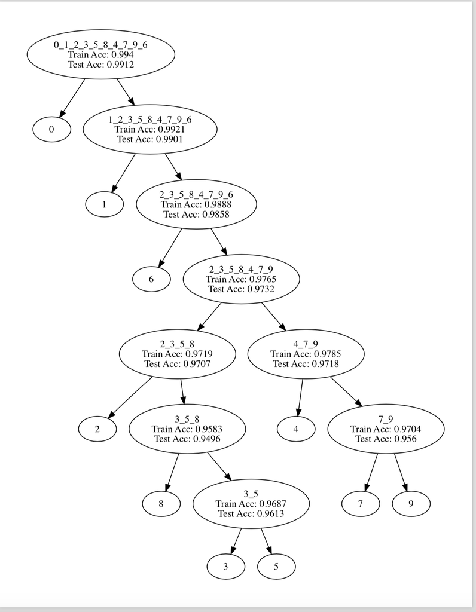

#### Question 6 :

```python
from nltk.tokenize import sent_tokenize, word_tokenize
from nltk.corpus import stopwords
from nltk.stem import WordNetLemmatizer
from nltk.stem import PorterStemmer,SnowballStemmer
from nltk import pos_tag
import re
```

```python
wnl = SnowballStemmer("english")
stop_words = stopwords.words('english')

def cleanTextandStemming(text):
    #text = re.sub(r"\s+", " ", text)
    text = re.sub('[^ a-zA-Z]',' ',text)
    text = re.sub(r' +', ' ', text)

    text=re.sub('\S*#(?:\[[^\]]+\]|\S+)+', ' ', text) #hastags
    text=re.sub('\S*@(?:\[[^\]]+\]|\S+)+', ' ', text) #mentions

    text=text.replace('\n',' ').replace('\r',' ') # line breaks and carriage returns

    text=text.replace("â€™"," ") #Special characters
    text=text.replace("â€"," ")  #Special characters

    text = re.sub(r"(http(s?))?://\S+",' ',text) #links wiht http(s)
    text = re.sub(r"(www)?[\S]+\.[\S]+\.[\S]+",' ',text) #links with just xyz.xyz.com

    text=re.sub(r"[.,/*-/?\'\"\\;:\[\]{}!@$^()]+"," ",text,re.DOTALL|re.U|re.I) #puntuations

    text = re.sub(r"\s+", " ", text) #whitespaces
    text = stemWords(text)
    return(text)

def stemWords(data):
    sentence=''
    for w in word_tokenize(data):
        word = ''
        if ((w not in stop_words) and len(w)>2):
            word = wnl.stem(w)
            sentence = sentence + " " + word.lower()
    return sentence
```

```python
path = r'/Users/rajmati.marlecha/Desktop/Term3/DMG2/20_newsgroups'
allFiles = []

for (dirpath, dirnames, filenames) in walk(path):
    #categories.append(dirpath)
    #print(dirnames)
    allFiles.extend([dirpath.split(os.path.sep)[-1],os.path.join(dirpath, x)] for x in filenames if (x.endswith(".DS_Store") != True))

newsgroupsDF= pd.DataFrame(allFiles, columns=['category','file'])
print(newsgroupsDF.count())
newsgroupsDF.head()
```

```
category    19997
file        19997
dtype: int64
```

|  | category | file |
| --- | --- | --- |
| 0 | talk.politics.mideast | /Users/rajmati.marlecha/Desktop/Term3/DMG2/20_... |
| 1 | talk.politics.mideast | /Users/rajmati.marlecha/Desktop/Term3/DMG2/20_... |
| 2 | talk.politics.mideast | /Users/rajmati.marlecha/Desktop/Term3/DMG2/20_... |
| 3 | talk.politics.mideast | /Users/rajmati.marlecha/Desktop/Term3/DMG2/20_... |
| 4 | talk.politics.mideast | /Users/rajmati.marlecha/Desktop/Term3/DMG2/20_... |

```python
from sklearn.model_selection import train_test_split
X_train, X_test, Y_train, Y_test = train_test_split(newsgroupsDF.file, newsgroupsDF.category, random_state=0, test_size=0.25)
print(X_train.shape)
print(X_test.shape)
```

```
(14997,)
(5000,)
```

```python
def readFile(fileobj):
    while True:
        data = fileobj.read()
        if not data:
            break
        yield data
```

```python
docList =[]
for fileobj in X_train:
    f = open(fileobj,'r',encoding="ISO-8859-1")
    for doc in readFile(f):
        #print("Before")
        #print(doc)
        cleanedText = cleanTextandStemming(doc)
        docList.append(cleanedText)
    f.close()
print(len(docList))
newsgroupsdataDF= pd.DataFrame(docList, columns=['doc'])
str(newsgroupsdataDF.doc[0])
```

```
14997
```

```
' path cantaloup srv cmu edu crabappl srv cmu edu ece cmu edu europa eng gtefsd com howland reston an net zaphod mps ohio state edu rphroy caen kuhub ukan edu wsuhub twsu edu krschimm newsgroup misc forsal subject amplifi speaker messag apr wsuhub twsu edu from krschimm wsuhub twsu edu karl schimmel…
```

```python
from sklearn.feature_extraction.text import CountVectorizer #referred tutorial code from TABA
vectorizer = CountVectorizer(min_df = 0.0001 , max_df= 0.99, stop_words="english")
features1 = pd.DataFrame(vectorizer.fit_transform(newsgroupsdataDF['doc']).toarray(),columns=vectorizer.get_feature_names())
features1.shape
```

```
(14997, 42957)
```

```python
wordDict = features1.sum().reset_index().sort_values(by=0,ascending=False).reset_index().iloc[:,1:3]
wordDict = wordDict.rename(columns={"index": "word", 0: "counts"})
print(wordDict.shape)
wordDict = wordDict.head(5000)
print(wordDict.shape)
wordDict.head()
```

```
(42957, 2)
(5000, 2)
```

|  | word | counts |
| --- | --- | --- |
| 0 | com | 37962 |
| 1 | apr | 31143 |
| 2 | news | 26250 |
| 3 | net | 19268 |
| 4 | state | 15676 |

```python
docsCountswithLabels = features1[wordDict.word.values].copy()
docsCounts.shape
```

```
(14997, 5000)
```

```python
docsCountswithLabels = features1[wordDict.word.values].copy()
docsCountswithLabels['category'] = Y_train.values
lambdaVal = 30
distinctWords = docsCountswithLabels.shape[1]
categories = np.unique(Y_train.values)
#def calculateProbability(word,category):
#word = 'soc'
#classVal = 'talk.politics.mideast'
#count of word in all documents of class class val
finalWord = []
finalWordProb = []
finalWordClass = []


for catVal in categories:
    subset = docsCountswithLabels[docsCountswithLabels['category']==catVal]
    #print(subset.shape)
    M = 0
    if M==0:
        M = subset.loc[:, subset.columns != 'category'].sum().reset_index().iloc[:,1:2].rename(columns={0: "counts"}).sum().values
    for word in wordDict.word:
        cntWordClass = 0
        deno = 0
        cntWordClass = subset[word].sum()
        # This the the calculation as per formula below in summary
        prob = round((lambdaVal + cntWordClass)/ (distinctWords + lambdaVal + M[0]),4)
        #print(prob)
        finalWord.append(word)
        finalWordClass.append(catVal)
        finalWordProb.append(prob)
summarWordsDF= pd.DataFrame({'word': finalWord ,'category': finalWordClass ,'probWordClass' : finalWordProb })
summarWordsDF.head()
#summarWordsDF.probWordClass.sum()
```

|  | word | category | probWordClass |
| --- | --- | --- | --- |
| 0 | com | alt.atheism | 0.017500 |
| 1 | apr | alt.atheism | 0.011400 |
| 2 | news | alt.atheism | 0.010700 |
| 3 | net | alt.atheism | 0.007900 |
| 4 | state | alt.atheism | 0.005600 |

```python
print(np.unique(summarWordsDF.word).shape)
summarWordsDF.head()
```

```
(5000,)
```

|  | word | category | probWordClass |
| --- | --- | --- | --- |
| 0 | com | alt.atheism | 0.017500 |
| 1 | apr | alt.atheism | 0.011400 |
| 2 | news | alt.atheism | 0.010700 |
| 3 | net | alt.atheism | 0.007900 |
| 4 | state | alt.atheism | 0.005600 |

```python
summarWordsDF.tail()
```

|  | word | category | probWordClass |
| --- | --- | --- | --- |
| 99995 | theporch | talk.religion.misc | 0.000200 |
| 99996 | cogsci | talk.religion.misc | 0.000200 |
| 99997 | mintaka | talk.religion.misc | 0.000200 |
| 99998 | tigger | talk.religion.misc | 0.000200 |
| 99999 | pole | talk.religion.misc | 0.000300 |

```python
summarWordsDF.sort_values(by='probWordClass' , ascending=False)
```

|  | word | category | probWordClass |
| --- | --- | --- | --- |
| 75041 | rutger | soc.religion.christian | 0.035600 |
| 10023 | window | comp.os.ms-windows.misc | 0.033200 |
| 10076 | max | comp.os.ms-windows.misc | 0.032600 |
| 40000 | com | rec.motorcycles | 0.032100 |
| 75040 | christian | soc.religion.christian | 0.027600 |
| 30161 | forsal | misc.forsale | 0.026200 |
| 35000 | com | rec.autos | 0.023800 |
| 25023 | window | comp.windows.x | 0.023200 |
| 30015 | misc | misc.forsale | 0.022600 |
| 20108 | mac | comp.sys.mac.hardware | 0.022500 |
| 70084 | space | sci.space | 0.022000 |
| 15000 | com | comp.sys.ibm.pc.hardware | 0.021500 |
| 40001 | apr | rec.motorcycles | 0.021400 |
| 10014 | comp | comp.os.ms-windows.misc | 0.020800 |
| 55000 | com | sci.crypt | 0.020400 |
| 95000 | com | talk.religion.misc | 0.020300 |
| 45001 | apr | rec.sport.baseball | 0.020300 |
| 35001 | apr | rec.autos | 0.019600 |
| 80000 | com | talk.politics.guns | 0.019500 |
| 5110 | graphic | comp.graphics | 0.019200 |
| 80090 | gun | talk.politics.guns | 0.018600 |
| 90000 | com | talk.politics.misc | 0.018000 |
| 50001 | apr | rec.sport.hockey | 0.017700 |
| 0 | com | alt.atheism | 0.017500 |
| 95012 | talk | talk.religion.misc | 0.017400 |
| 70031 | sci | sci.space | 0.017300 |
| 60000 | com | sci.electronics | 0.016900 |
| 45000 | com | rec.sport.baseball | 0.016900 |
| 60001 | apr | sci.electronics | 0.016900 |
| 25000 | com | comp.windows.x | 0.016500 |
| ... | ... | ... | ... |
| 58939 | character | sci.crypt | 0.000200 |
| 82521 | sgigat | talk.politics.guns | 0.000200 |
| 58940 | benedikt | sci.crypt | 0.000200 |
| 58941 | teeth | sci.crypt | 0.000200 |
| 82518 | newshub | talk.politics.guns | 0.000200 |
| 82539 | unknown | talk.politics.guns | 0.000200 |
| 82541 | baltimor | talk.politics.guns | 0.000200 |
| 58917 | cruel | sci.crypt | 0.000200 |
| 82554 | cit | talk.politics.guns | 0.000200 |
| 82565 | union | talk.politics.guns | 0.000200 |
| 82564 | winner | talk.politics.guns | 0.000200 |
| 58918 | lamp | sci.crypt | 0.000200 |
| 58919 | hasan | sci.crypt | 0.000200 |
| 58921 | pistol | sci.crypt | 0.000200 |
| 58923 | covington | sci.crypt | 0.000200 |
| 82557 | prime | talk.politics.guns | 0.000200 |
| 58924 | steveh | sci.crypt | 0.000200 |
| 82555 | hebrew | talk.politics.guns | 0.000200 |
| 82553 | philli | talk.politics.guns | 0.000200 |
| 82542 | bitmap | talk.politics.guns | 0.000200 |
| 58925 | boost | sci.crypt | 0.000200 |
| 82551 | ottawa | talk.politics.guns | 0.000200 |
| 82550 | depth | talk.politics.guns | 0.000200 |
| 82549 | variabl | talk.politics.guns | 0.000200 |
| 82548 | cpr | talk.politics.guns | 0.000200 |
| 58926 | investor | sci.crypt | 0.000200 |
| 58927 | admir | sci.crypt | 0.000200 |
| 82545 | comic | talk.politics.guns | 0.000200 |
| 82544 | symptom | talk.politics.guns | 0.000200 |
| 1871 | band | alt.atheism | 0.000200 |

100000 rows × 3 columns

```python
docList =[]
for fileobj in X_test:
    f = open(fileobj,'r',encoding="ISO-8859-1")
    for doc in readFile(f):
        #print("Before")
        #print(doc)
        cleanedText = cleanTextandStemming(doc)
        docList.append(cleanedText)
    f.close()
print(len(docList))
newsgroupsdataDF_Test= pd.DataFrame(docList, columns=['doc'])
str(newsgroupsdataDF_Test.doc[0])
```

```
5000
```

```
' xref cantaloup srv cmu edu gnu ghostscript bug comp window misc newsgroup gnu ghostscript bug comp window misc from ulkyvx louisvill edu steve brewer subject how make ghostscript work messag apr ulkyvx louisvill edu date fri apr gmt organ univers louisvill appar gnu ghostscript bug rutger edu dist…
```

```python
#df = Y_train.groupby
#Y_train_df= pd.DataFrame({'category': Y_train.values})
categories = np.unique(Y_train.values)
priors =[]
cats =[]
for cat in categories:
    priorClassProb = round(Y_train_df[(Y_train_df.category==cat)].shape[0] /Y_train_df.shape[0],4)
    cats.append(cat)
    priors.append(priorClassProb)
priorDF = pd.DataFrame({'cat' : cats,'priors' : priors })
print(priorDF.shape)
priorDF.head()
```

```
(20, 2)
```

|  | cat | priors |
| --- | --- | --- |
| 0 | alt.atheism | 0.050700 |
| 1 | comp.graphics | 0.050400 |
| 2 | comp.os.ms-windows.misc | 0.050700 |
| 3 | comp.sys.ibm.pc.hardware | 0.049600 |
| 4 | comp.sys.mac.hardware | 0.050100 |

```python
def calculateYPredicted(dataset):
    Y_pred =[]
    categories = np.unique(Y_train.values)
    #print(categories)
    iter2= 0
    for doc in dataset.doc[0:10]:
        iter2 = iter2+1
        print(iter2)
        probVals =[]
        catVals =[]
        for classVal in categories:
            prob = 1.0000
            for w in word_tokenize(doc):

                if w in wordDict.word.values:
                    #print(w)
                    probClass = summarWordsDF[(summarWordsDF.word==w) & (summarWordsDF.category==classVal)]['probWordClass']
                    if (len(probClass) > 0):
                        if(probClass.values[0] > 0):

                            #print(probClass.values[0])
                            prob = prob * probClass.values[0]
                            #print(prob)
                        else:
                            prob = prob * 0.0001 #later needed : if wordDict condition not present very small val for missing words # cant set to zero ,this might be needed for missing words on vocab
                    else:
                        prob = prob * 0.0001 #very small val for missing words # cant set to zero
            catVals.append(classVal)

            #print(prob)
            finalprob = prob*priorDF[priorDF.cat ==classVal]['priors'].values[0]

            probVals.append(finalprob) #multiply by prior
        b=np.argmax(probVals)
        #print(b)
        #print(catVals[b])
        Y_pred.append(catVals[b])
    return Y_pred
```

```python
Y_pred_train = calculateYPredicted(newsgroupsdataDF)
len(Y_pred_train)
```

```
1
2
3
4
5
6
7
8
9
10
```

```
10
```

```python
Y_pred_test = calculateYPredicted(newsgroupsdataDF_Test)
len(Y_pred_test)
```

```
1
2
3
4
5
6
7
8
9
10
```

```
10
```

```python
#Calcuate Accuracy
#Y_pred_train =
train_score = round(metrics.accuracy_score(Y_train[0:10], Y_pred_train),4)

#Y_pred_test
test_score = round(metrics.accuracy_score(Y_test[0:10], Y_pred_test),4)
print(train_score)
print(test_score)
```

```
0.3
0.6
```

#### Summary Q6:

- Here we are doing text classification using the naive bayes assumption
- We build the model on entire corpus give of all 20 folders
- We applied a smooting parameter Laplacian smooting(lambda in formula below) with a value of 30
- There are 20 categories in the news corpus
- We loaded the entire dataset and divided the entire newsfiles into train test of 75% and 25% resp
- We further load each document and try to do some preprocessing as below:
  - We remove punctuations , carriage returns , newline characters, special characters , hashtags etc in the clean text method
  - We remove stop words using the nltk package
  - We remove all the words that are less than 2 chars
  - We also do stemming using the Snowball stemmer to bring the root form of the word
  - Finally we send the lowercase letters for further processing
- The cleaned document is now further fed to count vectorizer that gives us the term frequecies
- The use of count vectorizer is multifold here
  - It removes the left-over junk and breaks the document into tokens to further give its frequencies
  - I use the same to further sort filter and get the top 5000 words that are most frequent for further processing
  - Once this new dict is formed , I used the same vectorizer output in dataframe to further give me frequencies of these new 5000 words
- Now summarWordsDF gets computed as per the formula
  - P(Wm|c) = (lambda + N(Wm|c))/(M + allmfrom1toMΣ N(Wm|c) + lambda ))
- We also compute priors of the 20 classes using the Y train dataset : priorDF
- Further we now build a predictor method calculateYPredicted which takes the dataset provided , and computes the probabilities of all the words as per
  - Using cross to denote multiply below
  - first tokenizes all the words of each doc provided , then calculate the probabilities as below
  - P(c|doc) = P(Wm1|c) cross P(Wm2|c) cross P(Wm3|c)....P(WmM|c) * PriorProb(c)
  - P(WmM|c) : is coming from summarWordsDF filtered for that word for that class
  - Where PriorProb is the prior probability of the class and is coming from priorDF that we computed
- Once we get the probabilities we check on which class did the max probability occur for the P(WmM|c) and we assign that class label for the dataset.
- We compute the accuracy for both test and train datasets with the predicted output from the calculateYPredicted function by passing the document corpus which returns us the class labels predicted , which we compare with the actuals to get the accuracies on both the dataset
- the cleansing and stemming steps are used and performed on the dataset before the documents are passed to the predictor
- We ran the model on train and test data , the train accuracy is 0.3 and test accuracy is 0.6
- We can run the model on more documents to get the overall train and test accuracies.
- The model also handles probability of new words that are not in dict , however its toggle based and can be altered if needed